# QTM151_Final_Project

## Insight 3: Homeless People and the Right to Healthcare

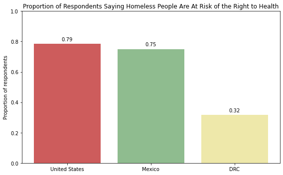

```python
right_to_health_var = 'health_atrisk_prop27'
df_health = pd.DataFrame({'Country': target_countries,'Proportion': [filtered_df[filtered_df['country'] == country][right_to_health_var].values[0]for country in target_countries]})
plt.figure(figsize=(8, 5))
colors = ['indianred', 'darkseagreen', 'palegoldenrod']  # one color per country
bars = plt.bar(df_health['Country'], df_health['Proportion'], color=colors)
plt.title("Proportion of Respondents Saying Homeless People Are At Risk of the Right to Health")
plt.ylabel("Proportion of respondents")
plt.ylim(0, 1)
for bar in bars:
    yval = bar.get_height()
    plt.text(bar.get_x() + bar.get_width() / 2, yval + 0.02, f"{yval:.2f}", ha='center')
plt.tight_layout()
plt.show()
```

## Conclusion:

##### After working on this project and working extensively with the codebook and datasets, we came to realize that the materials had some shortcomings. The codebook did not talk about how the study chose their respondents, which leads to the possibility that responses could be biased. The formatting of the people_at_risk dataset was also hard to understand at first, as each right was separated into its own column and it was difficult to locate the data we were looking for. However, the dataset does touch on pertinent issues and social groups that are often underrepresented in research.

## Works Cited

##### “McKinney-Vento – National Center for Homeless Education.” National Center for Homeless Education, nche.ed.gov/mckinneyvento/. Accessed 2 May 2025.

##### Bedmar, Miguel A., et al. “Health Status and Self-Perception of Health among Homeless People in Spain: A Mixed-Methods Study.” Frontiers in Public Health, vol. 12, 29 Aug. 2024, https://doi.org/10.3389/fpubh.2024.1444888.

##### “Education.” Unicef.org, 2018, www.unicef.org/drcongo/en/what-we-do/education?utm. Accessed 2 May 2025.

##### “Failing Our Children: Barriers to the Right to Education: IV. Discrimination and Lack of Access .” Www.hrw.org, www.hrw.org/reports/2005/education0905/6.htm. Accessed 2 May 2025.

##### Le Minh Kieu, and G. Senanayake. “Perception, Experience and Resilience to Risks: A Global Analysis.” Scientific Reports, vol. 13, no. 1, 7 Nov. 2023, www.ncbi.nlm.nih.gov/pmc/articles/PMC10630481/, https://doi.org/10.1038/s41598-023-46680-1.

##### United Nations. “Homelessness and Human Rights.” OHCHR, United Nations, 2022, www.ohchr.org/en/special-procedures/sr-housing/homelessness-and-human-rights.